# Nb_PVY

Bibechana Paudel

2025-10-29

# Libraries used

```r
#install.packages("tidyverse")
#install.packages("ggplot2")
#install.packages("agricolae")
#install.packages("tidyr")
#install.packages("ggpubr")
#install.packages("multcomp")
#install.packages("emmeans")
#install.packages("multcompView")
library(tidyverse)
library(ggplot2)
library(agricolae)
library(tidyr)
library(ggpubr)
library(multcomp)
library(emmeans)
library(multcompView)
```

## Load the data

```r
rep1 <- read.csv("Data-obj1-New/Nb_PVY_1st_trial_New.csv", header=T)
head(rep1)  # View the first few rows
```

```
##    Dpi Rep    Cq
## 1 IL-1   1 19.72
## 2 IL-1   2 19.56
## 3 IL-1   3 19.98
## 4 IL-4   1 17.55
## 5 IL-4   2 17.48
## 6 IL-4   3 17.58
```

```r
str(rep1)   # Check the structure of the data
```

```
## 'data.frame':    18 obs. of  3 variables:
##  $ Dpi: chr  "IL-1" "IL-1" "IL-1" "IL-4" ...
##  $ Rep: int  1 2 3 1 2 3 1 2 3 1 ...
##  $ Cq : num  19.7 19.6 20 17.6 17.5 ...
```

```r
summary(rep1) # Quick statistical summary
```

```
##      Dpi                 Rep          Cq
##  Length:18          Min.   :1   Min.   :15.98
##  Class :character   1st Qu.:1   1st Qu.:16.26
##  Mode  :character   Median :2   Median :18.57
##                     Mean   :2   Mean   :20.41
##                     3rd Qu.:3   3rd Qu.:26.04
##                     Max.   :3   Max.   :26.80
```

###Make the factor variable

```r
rep1$Dpi<-as.factor(rep1$Dpi)
```

## Viral load

##Calculate the ViralLoad using the regression equation derived by (Feng , J.L et al., 2006 ) and log transform for normality.

[Feng, J.L et al., 2006](https://academic.oup.com/abbs/article/38/10/669/217)

```r
rep1<-rep1 %>%
mutate (ViralLoad=((10^((Cq-49.153)/-3.93)))) %>% ##added a new column and named ViralLoad
mutate(logViralLoad=log10(ViralLoad))  ##added a new column and named logViralLoad
```

##Classify the sample collection days based on leaf

```r
rep1$Leaf_sample<- ifelse(
  grepl("^IL", rep1$Dpi), "Inoculated",  # Matches Dpi values starting with IL
  ifelse(grepl("^SL", rep1$Dpi), "Systemic", NA)
)
```

##Data summarization

```r
PVY1 <- rep1 %>%  # Start with the dataset `rep1` and pipe (%>%) it into the next operations
  group_by(Dpi, Leaf_sample) %>%   # Group the data by treatment type and days post-inoculation (Dpi)
  dplyr::summarize(
    avg.virus= mean(logViralLoad, na.rm=TRUE),
    n=n(),
    se = sd(logViralLoad)/sqrt(n)) # join the significant letters with the PVY1 data frame.
```

```
## argument.
```

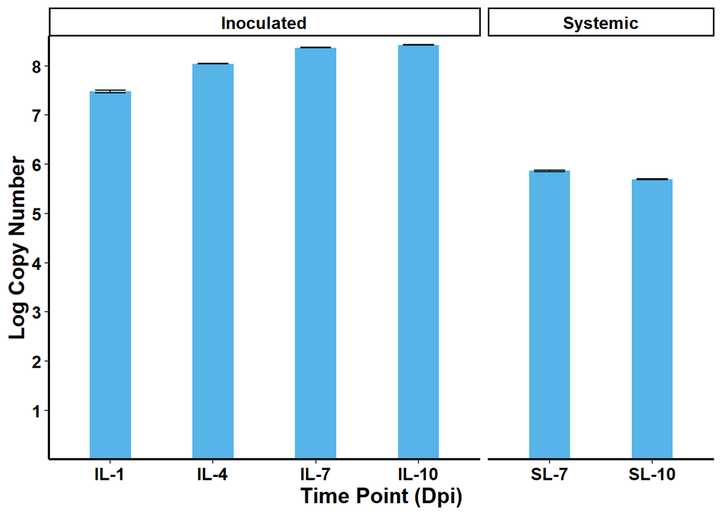

```r
PVY_1 <- ggplot(PVY1,aes(x =factor(Dpi,levels=c("IL-1", "IL-4", "IL-7", "IL-10","SL-7", "SL-10")), y = avg.virus)) +
  stat_summary(fun=mean,geom="bar", position = position_dodge(width = 0.3), width = 0.4, fill="#56B4E9") +
   geom_errorbar(aes(ymin = avg.virus - se,
                    ymax = avg.virus + se),
                width = 0.3,
                position = position_dodge(width = 0.3)) +
  labs(x = "Time Point (Dpi)", y = "Log Copy Number") +
  theme_classic() +
  theme(plot.title = element_text(hjust = 0.5),
        strip.text = element_text(face = "bold", size = 12, color = "black"),
        legend.position = "none",
        axis.text.x = element_text(color = "black", face="bold", size=12),   # X-axis text color
        axis.text.y = element_text(color = "black", face="bold", size=12),   # Y-axis text color
        axis.title.x = element_text(color = "black", face="bold", size=15),  # X-axis label color
        axis.title.y = element_text(color = "black", face="bold", size=15),  # Y-axis label color
        axis.line = element_line(color = "black", size=0.75)      # Axis lines color
  ) +
  scale_y_continuous(
    expand = expansion(mult = c(0, 0.02)), breaks = seq(1, 9, by = 1)  # This removes padding at the bottom of the plot
  )+
   scale_x_discrete(drop = TRUE) +
  facet_grid(~Leaf_sample, scale="free_x", space="free_x")# Sets y-axis limits but removes points outside 0-8
PVY_1
```

# **Second trial**

## Load the data

```r
rep2 <- read.csv("Data-obj1-New/Nb_PVY_2nd_trial_New.csv", header=T)
head(rep2)  # View the first few rows
```

```
##    Dpi Rep    Cq
## 1 IL-1   1 23.18
## 2 IL-1   2 23.28
## 3 IL-1   3 23.34
## 4 IL-4   1 21.99
## 5 IL-4   2 20.61
## 6 IL-4   3 22.01
```

```r
str(rep2)   # Check the structure of the data
```

```
## 'data.frame':    21 obs. of  3 variables:
##  $ Dpi: chr  "IL-1" "IL-1" "IL-1" "IL-4" ...
##  $ Rep: int  1 2 3 1 2 3 1 2 3 1 ...
##  $ Cq : num  23.2 23.3 23.3 22 20.6 ...
```

```r
summary(rep2) # Quick statistical summary
```

```
##      Dpi                 Rep          Cq
##  Length:21          Min.   :1   Min.   :15.28
##  Class :character   1st Qu.:1   1st Qu.:20.02
##  Mode  :character   Median :2   Median :21.99
##                     Mean   :2   Mean   :22.86
##                     3rd Qu.:3   3rd Qu.:27.49
##                     Max.   :3   Max.   :30.11
```

###Make the factor variable

```r
rep2$Dpi<-as.factor(rep2$Dpi)
```

## Viral load

##Calculate the ViralLoad using the regression equation derived by (Feng , J.L et al., 2006 ) and log transform for normality.

[Feng, J.L et al., 2006](https://academic.oup.com/abbs/article/38/10/669/217)

```r
rep2<-rep2 %>%
mutate (ViralLoad=((10^((Cq-49.153)/-3.93)))) %>%##added a new column and named ViralLoad
mutate(logViralLoad=log10(ViralLoad)) %>%
  filter(rep2$Dpi!="SL-14")##added a new column and named logViralLoad
```

##Classify the sample collection days based on leaf

```r
rep2$Leaf_sample<- ifelse(
  grepl("^IL", rep2$Dpi), "Inoculated",  # Matches Dpi values starting with IL
  ifelse(grepl("^SL", rep2$Dpi), "Systemic", NA)
)
```

##Data summarization

```r
PVY2 <- rep2 %>%  # Start with the dataset `rep2` and pipe (%>%) it into the next operations
  group_by(Dpi, Leaf_sample) %>%   # Group the data by treatment type and days post-inoculation (Dpi)
  dplyr::summarize(
    avg.virus= mean(logViralLoad, na.rm=TRUE),
    n=n(),
    se = sd(logViralLoad)/sqrt(n)) # join the significant letters with the PVY1 data frame.
```

```
## argument.
```

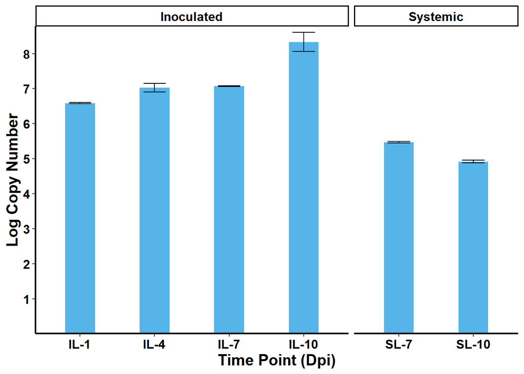

```r
PVY_2 <- ggplot(PVY2,aes(x =factor(Dpi,levels=c("IL-1", "IL-4", "IL-7", "IL-10","SL-7", "SL-10")), y = avg.virus)) +
  stat_summary(fun=mean,geom="bar", position = position_dodge(width = 0.3), width = 0.4, fill="#56B4E9") +
   geom_errorbar(aes(ymin = avg.virus - se,
                    ymax = avg.virus + se),
                width = 0.3,
                position = position_dodge(width = 0.3)) +
  labs(x = "Time Point (Dpi)", y = "Log Copy Number") +
  theme_classic() +
  theme(plot.title = element_text(hjust = 0.5),
        strip.text = element_text(face = "bold", size = 12, color = "black"),
        legend.position = "none",
        axis.text.x = element_text(color = "black", face="bold", size=12),   # X-axis text color
        axis.text.y = element_text(color = "black", face="bold", size=12),   # Y-axis text color
        axis.title.x = element_text(color = "black", face="bold", size=15),  # X-axis label color
        axis.title.y = element_text(color = "black", face="bold", size=15),  # Y-axis label color
        axis.line = element_line(color = "black", size=0.75)      # Axis lines color
  ) +
  scale_y_continuous(
    expand = expansion(mult = c(0, 0.02)), breaks = seq(1, 9, by = 1)  # This removes padding at the bottom of the plot
  )+
   scale_x_discrete(drop = TRUE) +
  facet_grid(~Leaf_sample, scale="free_x", space="free_x")# Sets y-axis limits but removes points outside 0-8

PVY_2
```

# **Supplementary First Trial**

## Load the data

```r
rep1_PVY3_1ng <- read.csv("Data-obj1-New/Nb_PVY_1st_PVY3_1ng.csv", header=T)
head(rep1_PVY3_1ng)  # View the first few rows
```

```
##    Dpi Rep    Cq
## 1 IL-1   1 25.39
## 2 IL-1   2 25.54
## 3 IL-1   3 25.34
## 4 IL-4   1 22.26
## 5 IL-4   2 22.31
## 6 IL-4   3 22.45
```

```r
str(rep1_PVY3_1ng)   # Check the structure of the data
```

```
## 'data.frame':    18 obs. of  3 variables:
##  $ Dpi: chr  "IL-1" "IL-1" "IL-1" "IL-4" ...
##  $ Rep: int  1 2 3 1 2 3 1 2 3 1 ...
##  $ Cq : num  25.4 25.5 25.3 22.3 22.3 ...
```

```r
summary(rep1_PVY3_1ng) # Quick statistical summary
```

```
##      Dpi                 Rep          Cq
##  Length:18          Min.   :1   Min.   :19.81
##  Class :character   1st Qu.:1   1st Qu.:21.37
##  Mode  :character   Median :2   Median :23.89
##                     Mean   :2   Mean   :25.10
##                     3rd Qu.:3   3rd Qu.:30.51
##                     Max.   :3   Max.   :31.53
```

###Make the factor variable

```r
rep1_PVY3_1ng$Dpi<-as.factor(rep1_PVY3_1ng$Dpi)
```

## Viral load

##Calculate the ViralLoad using the regression equation derived by (Feng , J.L et al., 2006 ) and log transform for normality.

[Feng, J.L et al., 2006](https://academic.oup.com/abbs/article/38/10/669/217)

```r
rep1_PVY3_1ng<-rep1_PVY3_1ng %>%
mutate (ViralLoad=((10^((Cq-49.153)/-3.93)))) %>% ##added a new column and named ViralLoad
mutate(logViralLoad=log10(ViralLoad))  ##added a new column and named logViralLoad
```

##Classify the sample collection days based on leaf

```r
rep1_PVY3_1ng$Leaf_sample<- ifelse(
  grepl("^IL", rep1_PVY3_1ng$Dpi), "Inoculated",  # Matches Dpi values starting with IL
  ifelse(grepl("^SL", rep1_PVY3_1ng$Dpi), "Systemic", NA)
)
```

##Data summarization

```r
PVY1 <- rep1_PVY3_1ng %>%  # Start with the dataset `rep1` and pipe (%>%) it into the next operations
  group_by(Dpi, Leaf_sample) %>%   # Group the data by treatment type and days post-inoculation (Dpi)
  dplyr::summarize(
    avg.virus= mean(logViralLoad, na.rm=TRUE),
    n=n(),
    se = sd(logViralLoad)/sqrt(n)) # join the significant letters with the PVY1 data frame.
```

```
## argument.
```

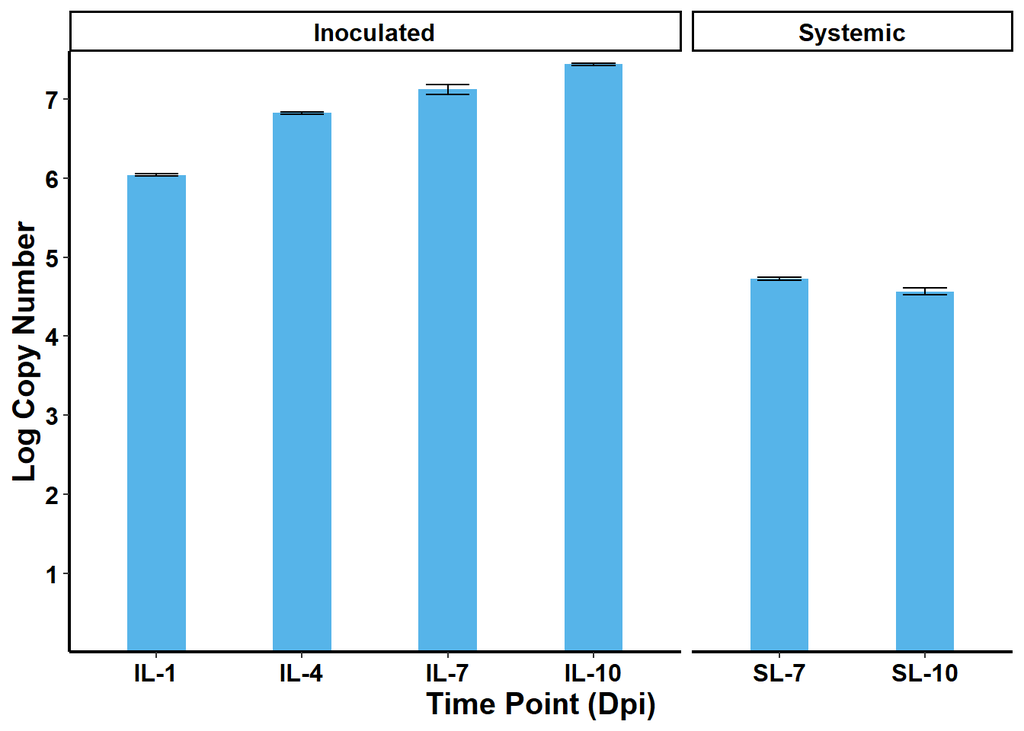

```r
PVY_1_PVY3_1ng <- ggplot(PVY1,aes(x =factor(Dpi,levels=c("IL-1", "IL-4", "IL-7", "IL-10","SL-7", "SL-10")), y = avg.virus)) +
  stat_summary(fun=mean,geom="bar", position = position_dodge(width = 0.3), width = 0.4, fill="#56B4E9") +
   geom_errorbar(aes(ymin = avg.virus - se,
                    ymax = avg.virus + se),
                width = 0.3,
                position = position_dodge(width = 0.3)) +
  labs(x = "Time Point (Dpi)", y = "Log Copy Number") +
  theme_classic() +
  theme(plot.title = element_text(hjust = 0.5),
        strip.text = element_text(face = "bold", size = 12, color = "black"),
        legend.position = "none",
        axis.text.x = element_text(color = "black", face="bold", size=12),   # X-axis text color
        axis.text.y = element_text(color = "black", face="bold", size=12),   # Y-axis text color
        axis.title.x = element_text(color = "black", face="bold", size=15),  # X-axis label color
        axis.title.y = element_text(color = "black", face="bold", size=15),  # Y-axis label color
        axis.line = element_line(color = "black", size=0.75)      # Axis lines color
  ) +
  scale_y_continuous(
    expand = expansion(mult = c(0, 0.02)), breaks = seq(1, 9, by = 1)  # This removes padding at the bottom of the plot
  )+
   scale_x_discrete(drop = TRUE) +
  facet_grid(~Leaf_sample, scale="free_x", space="free_x")# Sets y-axis limits but removes points outside 0-8


PVY_1_PVY3_1ng
```

## PVY3_Nb

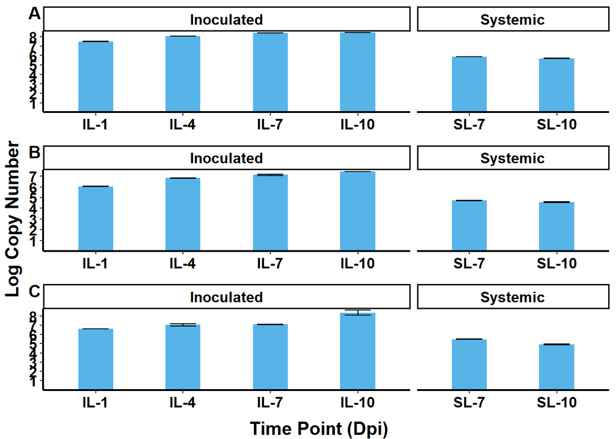

```r
PVY_1 <- PVY_1 +
  labs(x = NULL, y = NULL) + #Remove x and y labels
  theme(axis.title = element_blank()) # Remove axis titles
PVY_1_PVY3_1ng<-PVY_1_PVY3_1ng+
  labs(x = NULL, y = NULL) +
  theme(axis.title = element_blank())

PVY_2 <- PVY_2 +
  labs(x = NULL, y = NULL) +
  theme(axis.title = element_blank())
# Combine figures and add shared axis titles
combined_plot_PVY3 <- ggarrange(
  PVY_1,
  PVY_1_PVY3_1ng,
  PVY_2,
  ncol = 1,
  labels = c("A", "B", "C"),
  align = "v"      # vertically align plots
)

# Add shared axis titles
combined_plot_PVY3_annotated <- annotate_figure(
  combined_plot_PVY3,
  bottom = text_grob("Time Point (Dpi)", size = 15, face="bold"),
  left = text_grob("Log Copy Number", rot = 90, size = 15, face="bold")
)
combined_plot_PVY3_annotated
```

## Load the data

```r
rep1_PVY1_10ng <- read.csv("Data-obj1-New/Nb_PVY_1st_PVY1_10ng.csv", header=T)
head(rep1_PVY1_10ng)  # View the first few rows
```

```
##    Dpi Rep    Cq
## 1 IL-1   1 20.46
## 2 IL-1   2 20.52
## 3 IL-1   3 20.19
## 4 IL-4   1 18.40
## 5 IL-4   2 18.19
## 6 IL-4   3 18.32
```

```r
str(rep1_PVY1_10ng)   # Check the structure of the data
```

```
## 'data.frame':    18 obs. of  3 variables:
##  $ Dpi: chr  "IL-1" "IL-1" "IL-1" "IL-4" ...
##  $ Rep: int  1 2 3 1 2 3 1 2 3 1 ...
##  $ Cq : num  20.5 20.5 20.2 18.4 18.2 ...
```

```r
summary(rep1_PVY1_10ng) # Quick statistical summary
```

```
##      Dpi                 Rep          Cq
##  Length:18          Min.   :1   Min.   :16.65
##  Class :character   1st Qu.:1   1st Qu.:16.98
##  Mode  :character   Median :2   Median :19.30
##                     Mean   :2   Mean   :21.06
##                     3rd Qu.:3   3rd Qu.:26.53
##                     Max.   :3   Max.   :27.44
```

###Make the factor variable

```r
rep1_PVY1_10ng$Dpi<-as.factor(rep1_PVY1_10ng$Dpi)
```

## Viral load

##Calculate the ViralLoad using the regression equation derived by (Feng , J.L et al., 2006 ) and log transform for normality.

[Feng, J.L et al., 2006](https://academic.oup.com/abbs/article/38/10/669/217)

```r
rep1_PVY1_10ng<-rep1_PVY1_10ng %>%
mutate (ViralLoad=((10^((Cq-49.153)/-3.93)))) %>% ##added a new column and named ViralLoad
mutate(logViralLoad=log10(ViralLoad))  ##added a new column and named logViralLoad
```

##Classify the sample collection days based on leaf

```r
rep1_PVY1_10ng$Leaf_sample<- ifelse(
  grepl("^IL", rep1_PVY1_10ng$Dpi), "Inoculated",  # Matches Dpi values starting with IL
  ifelse(grepl("^SL", rep1_PVY1_10ng$Dpi), "Systemic", NA)
)
```

##Data summarization

```r
PVY1 <- rep1_PVY1_10ng %>%  # Start with the dataset `rep1` and pipe (%>%) it into the next operations
  group_by(Dpi, Leaf_sample) %>%   # Group the data by treatment type and days post-inoculation (Dpi)
  dplyr::summarize(
    avg.virus= mean(logViralLoad, na.rm=TRUE),
    n=n(),
    se = sd(logViralLoad)/sqrt(n)) # join the significant letters with the PVY1 data frame.
```

```
## argument.
```

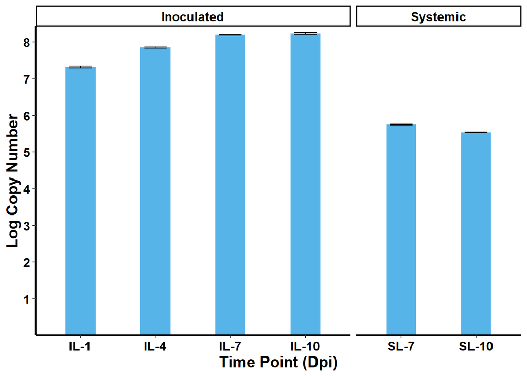

```r
PVY_1_PVY1_10ng <- ggplot(PVY1,aes(x =factor(Dpi,levels=c("IL-1", "IL-4", "IL-7", "IL-10","SL-7", "SL-10")), y = avg.virus)) +
  stat_summary(fun=mean,geom="bar", position = position_dodge(width = 0.3), width = 0.4, fill="#56B4E9") +
   geom_errorbar(aes(ymin = avg.virus - se,
                    ymax = avg.virus + se),
                width = 0.3,
                position = position_dodge(width = 0.3)) +
  labs(x = "Time Point (Dpi)", y = "Log Copy Number") +
  theme_classic() +
  theme(plot.title = element_text(hjust = 0.5),
        strip.text = element_text(face = "bold", size = 12, color = "black"),
        legend.position = "none",
        axis.text.x = element_text(color = "black", face="bold", size=12),   # X-axis text color
        axis.text.y = element_text(color = "black", face="bold", size=12),   # Y-axis text color
        axis.title.x = element_text(color = "black", face="bold", size=15),  # X-axis label color
        axis.title.y = element_text(color = "black", face="bold", size=15),  # Y-axis label color
        axis.line = element_line(color = "black", size=0.75)      # Axis lines color
  ) +
  scale_y_continuous(
    expand = expansion(mult = c(0, 0.02)), breaks = seq(1, 9, by = 1)  # This removes padding at the bottom of the plot
  )+
   scale_x_discrete(drop = TRUE) +
  facet_grid(~Leaf_sample, scale="free_x", space="free_x")# Sets y-axis limits but removes points outside 0-8

PVY_1_PVY1_10ng
```

## Load the data

```r
rep1_PVY1_1ng <- read.csv("Data-obj1-New/Nb_PVY_1st_PVY1_1ng.csv", header=T)
head(rep1_PVY1_1ng)  # View the first few rows
```

```
##    Dpi Rep    Cq
## 1 IL-1   1 26.17
## 2 IL-1   2 26.59
## 3 IL-1   3 26.62
## 4 IL-4   1 23.05
## 5 IL-4   2 23.24
## 6 IL-4   3 23.07
```

```r
str(rep1_PVY1_1ng)   # Check the structure of the data
```

```
## 'data.frame':    18 obs. of  3 variables:
##  $ Dpi: chr  "IL-1" "IL-1" "IL-1" "IL-4" ...
##  $ Rep: int  1 2 3 1 2 3 1 2 3 1 ...
##  $ Cq : num  26.2 26.6 26.6 23.1 23.2 ...
```

```r
summary(rep1_PVY1_1ng) # Quick statistical summary
```

```
##      Dpi                 Rep          Cq
##  Length:18          Min.   :1   Min.   :20.54
##  Class :character   1st Qu.:1   1st Qu.:22.20
##  Mode  :character   Median :2   Median :24.70
##                     Mean   :2   Mean   :26.23
##                     3rd Qu.:3   3rd Qu.:30.86
##                     Max.   :3   Max.   :33.18
```

###Make the factor variable

```r
rep1_PVY1_1ng$Dpi<-as.factor(rep1_PVY1_1ng$Dpi)
```

## Viral load

##Calculate the ViralLoad using the regression equation derived by (Feng , J.L et al., 2006 ) and log transform for normality.

[Feng, J.L et al., 2006](https://academic.oup.com/abbs/article/38/10/669/217)

```r
rep1_PVY1_1ng<-rep1_PVY1_1ng %>%
mutate (ViralLoad=((10^((Cq-49.153)/-3.93)))) %>% ##added a new column and named ViralLoad
mutate(logViralLoad=log10(ViralLoad))  ##added a new column and named logViralLoad
```

##Classify the sample collection days based on leaf

```r
rep1_PVY1_1ng$Leaf_sample<- ifelse(
  grepl("^IL", rep1_PVY1_1ng$Dpi), "Inoculated",  # Matches Dpi values starting with IL
  ifelse(grepl("^SL", rep1_PVY1_1ng$Dpi), "Systemic", NA)
)
```

##Data summarization

```r
PVY1 <- rep1_PVY1_1ng %>%  # Start with the dataset `rep1` and pipe (%>%) it into the next operations
  group_by(Dpi, Leaf_sample) %>%   # Group the data by treatment type and days post-inoculation (Dpi)
  dplyr::summarize(
    avg.virus= mean(logViralLoad, na.rm=TRUE),
    n=n(),
    se = sd(logViralLoad)/sqrt(n)) # join the significant letters with the PVY1 data frame.
```

```
## argument.
```

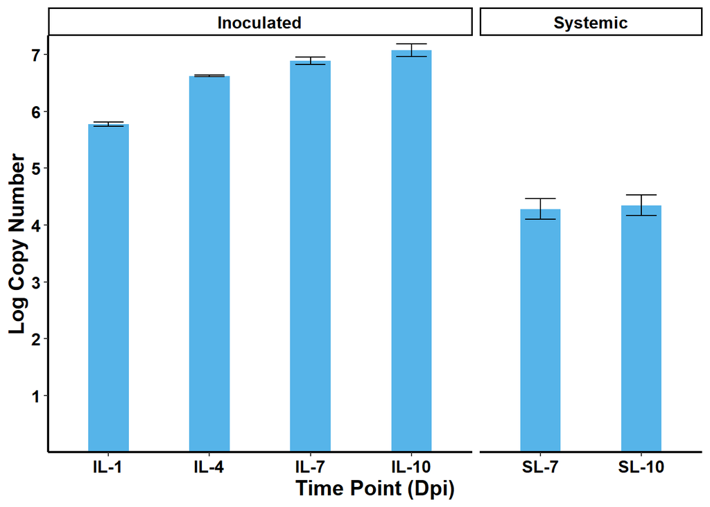

```r
PVY_1_PVY1_1ng <- ggplot(PVY1,aes(x =factor(Dpi,levels=c("IL-1", "IL-4", "IL-7", "IL-10","SL-7", "SL-10")), y = avg.virus)) +
  stat_summary(fun=mean,geom="bar", position = position_dodge(width = 0.3), width = 0.4, fill="#56B4E9") +
   geom_errorbar(aes(ymin = avg.virus - se,
                    ymax = avg.virus + se),
                width = 0.3,
                position = position_dodge(width = 0.3)) +
  labs(x = "Time Point (Dpi)", y = "Log Copy Number") +
  theme_classic() +
  theme(plot.title = element_text(hjust = 0.5),
        strip.text = element_text(face = "bold", size = 12, color = "black"),
        legend.position = "none",
        axis.text.x = element_text(color = "black", face="bold", size=12),   # X-axis text color
        axis.text.y = element_text(color = "black", face="bold", size=12),   # Y-axis text color
        axis.title.x = element_text(color = "black", face="bold", size=15),  # X-axis label color
        axis.title.y = element_text(color = "black", face="bold", size=15),  # Y-axis label color
        axis.line = element_line(color = "black", size=0.75)      # Axis lines color
  ) +
  scale_y_continuous(
    expand = expansion(mult = c(0, 0.02)), breaks = seq(1, 9, by = 1)  # This removes padding at the bottom of the plot
  )+
   scale_x_discrete(drop = TRUE) +
  facet_grid(~Leaf_sample, scale="free_x", space="free_x")# Sets y-axis limits but removes points outside 0-8
PVY_1_PVY1_1ng
```

# **Supplementary Second trial**

## Load the data

```r
rep2_PVY1_10ng <-read.csv("Data-obj1-New/Nb_PVY_2nd_PVY1_10ng.csv", header=T)
head(rep2_PVY1_10ng)  # View the first few rows
```

```
##    Dpi Rep    Cq
## 1 IL-1   1 24.33
## 2 IL-1   2 24.33
## 3 IL-1   3 24.40
## 4 IL-4   1 21.71
## 5 IL-4   2 21.79
## 6 IL-4   3 21.77
```

```r
str(rep2_PVY1_10ng)   # Check the structure of the data
```

```
## 'data.frame':    21 obs. of  3 variables:
##  $ Dpi: chr  "IL-1" "IL-1" "IL-1" "IL-4" ...
##  $ Rep: int  1 2 3 1 2 3 1 2 3 1 ...
##  $ Cq : num  24.3 24.3 24.4 21.7 21.8 ...
```

```r
summary(rep2_PVY1_10ng) # Quick statistical summary
```

```
##      Dpi                 Rep          Cq
##  Length:21          Min.   :1   Min.   :16.37
##  Class :character   1st Qu.:1   1st Qu.:21.12
##  Mode  :character   Median :2   Median :22.52
##                     Mean   :2   Mean   :23.76
##                     3rd Qu.:3   3rd Qu.:28.96
##                     Max.   :3   Max.   :31.32
```

###Make the factor variable

```r
rep2_PVY1_10ng$Dpi<-as.factor(rep2_PVY1_10ng$Dpi)
```

## Viral load

##Calculate the ViralLoad using the regression equation derived by (Feng , J.L et al., 2006 ) and log transform for normality.

[Feng, J.L et al., 2006](https://academic.oup.com/abbs/article/38/10/669/217)

```r
rep2_PVY1_10ng<-rep2_PVY1_10ng %>%
mutate (ViralLoad=((10^((Cq-49.153)/-3.93)))) %>% ##added a new column and named ViralLoad
mutate(logViralLoad=log10(ViralLoad)) %>%
  filter(Dpi!="SL-14")##added a new column and named logViralLoad
```

##Classify the sample collection days based on leaf

```r
rep2_PVY1_10ng$Leaf_sample<- ifelse(
  grepl("^IL", rep2_PVY1_10ng$Dpi), "Inoculated",  # Matches Dpi values starting with IL
  ifelse(grepl("^SL", rep2_PVY1_10ng$Dpi), "Systemic", NA)
)
```

##Data summarization

```r
PVY2 <- rep2_PVY1_10ng %>%  # Start with the dataset `rep2_PVY1_10ng` and pipe (%>%) it into the next operations
  group_by(Dpi, Leaf_sample) %>%   # Group the data by treatment type and days post-inoculation (Dpi)
  dplyr::summarize(
    avg.virus= mean(logViralLoad, na.rm=TRUE),
    n=n(),
    se = sd(logViralLoad)/sqrt(n)) # join the significant letters with the PVY1 data frame.
```

```
## argument.
```

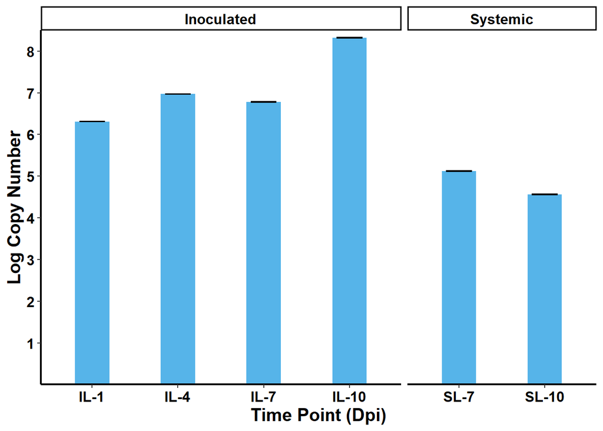

```r
PVY_2_PVY1_10ng <- ggplot(PVY2,aes(x =factor(Dpi,levels=c("IL-1", "IL-4", "IL-7", "IL-10","SL-7", "SL-10")), y = avg.virus)) +
  stat_summary(fun=mean,geom="bar", position = position_dodge(width = 0.3), width = 0.4, fill="#56B4E9") +
   geom_errorbar(aes(ymin = avg.virus - se,
                    ymax = avg.virus + se),
                width = 0.3,
                position = position_dodge(width = 0.3)) +
  labs(x = "Time Point (Dpi)", y = "Log Copy Number") +
  theme_classic() +
  theme(plot.title = element_text(hjust = 0.5),
        strip.text = element_text(face = "bold", size = 12, color = "black"),
        legend.position = "none",
        axis.text.x = element_text(color = "black", face="bold", size=12),   # X-axis text color
        axis.text.y = element_text(color = "black", face="bold", size=12),   # Y-axis text color
        axis.title.x = element_text(color = "black", face="bold", size=15),  # X-axis label color
        axis.title.y = element_text(color = "black", face="bold", size=15),  # Y-axis label color
        axis.line = element_line(color = "black", size=0.75)      # Axis lines color
  ) +
  scale_y_continuous(
    expand = expansion(mult = c(0, 0.02)), breaks = seq(1, 9, by = 1)  # This removes padding at the bottom of the plot
  )+
   scale_x_discrete(drop = TRUE) +
  facet_grid(~Leaf_sample, scale="free_x", space="free_x")# Sets y-axis limits but removes points outside 0-8

PVY_2_PVY1_10ng
```

## PVY1_Nb

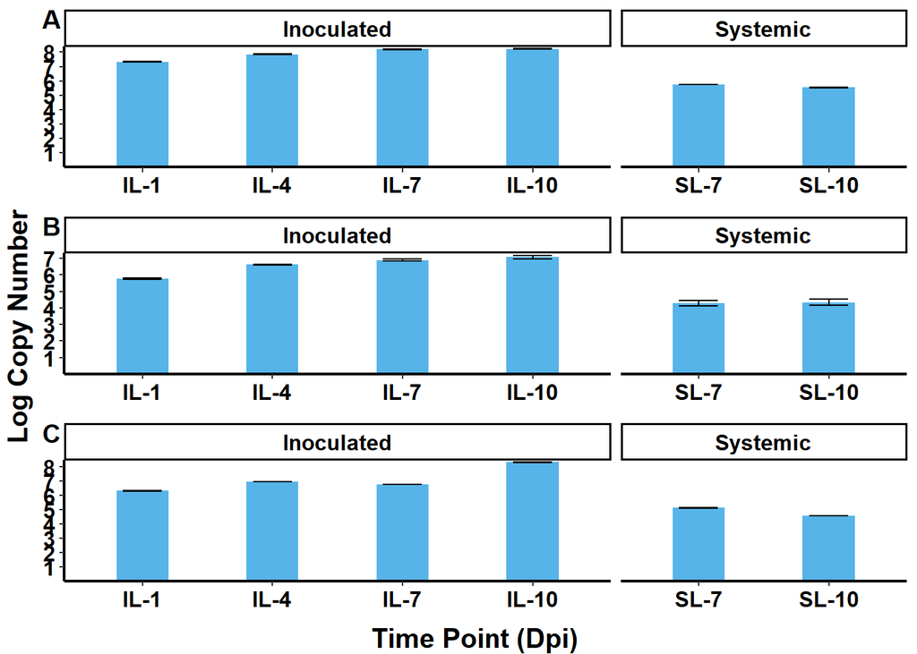

```r
PVY_1_PVY1_10ng <- PVY_1_PVY1_10ng +
  labs(x = NULL, y = NULL) +
  theme(axis.title = element_blank())
PVY_1_PVY1_1ng<-PVY_1_PVY1_1ng+
  labs(x = NULL, y = NULL) +
  theme(axis.title = element_blank())

PVY_2_PVY1_10ng <- PVY_2_PVY1_10ng +
  labs(x = NULL, y = NULL) +
  theme(axis.title = element_blank())
combined_plot_PVY1 <- ggarrange(
  PVY_1_PVY1_10ng,
  PVY_1_PVY1_1ng,
  PVY_2_PVY1_10ng,
  ncol = 1,
  labels = c("A", "B", "C"),
  align = "v"      # vertically align plots
)

# Add shared axis titles
combined_plot_PVY1_annotated <- annotate_figure(
  combined_plot_PVY1,
  bottom = text_grob("Time Point (Dpi)", size = 15, face="bold"),
  left = text_grob("Log Copy Number", rot = 90, size = 15, face="bold")
)
combined_plot_PVY1_annotated
```